# Clustering of candidate effectors across all genomes

*Note:* *if* *you* *wish* *to* *hide* *the* *code*, *please* *select* “Hide All Code” *the* *dropdown* *in* *the* *top* *right* *hand* *corner.*

A set of candidate effectors identified using the pipeline developed in-house were blasted back (BLASTP, 1e-6 cutoff) against the 10 genome sequences used in the study, to indicate the presence and frequency of these candidate effectors across the genomes.

CURRENT WORKING DIRECTORY:

```r
#Jamie Pike 26/3/2021

#Pheatmap clusters by euclidean distance

##Used as a guide for this: https://www.youtube.com/watch?v=pTeTH9bz-_s

#Set libraries
#install.packages("tidyverse")
library(tidyverse)
library(pheatmap)
library(matrixStats)
library(knitr)
library(ggplot2)


getwd()
```

```
[1] "/Users/u1983390/Documents/Lab_Book/Candidate_Effectors"
```

```r
setwd("/Users/u1983390/Documents/Lab_Book/Candidate_Effectors/")

Effectors <- read.csv("transposed_list_of_effectors_in_genomes.csv")
```

The table below indicates the number of BLASTP hits for each of the candidate effectors across all 10 genomes used in this study (Hits are counted where the sequences has => 905 identity).

```r
# #Indicate the number of rows and columns in the csv.
# print("nrow in csv:")
# nrow(Effectors) #Should equal the number of genomes.
# print("ncolv in csv:")
# ncol(Effectors) #Should equal the number of candidate effectors.

#Set Heatmap data.
Effectors %>%
  select(1:11) -> selected_heatmap #n = 73 as we do not want to include the race data in the last column.

print(selected_heatmap)
```

| Candidate_effectors | GCA_000260195.2_FO_II5_V1 | GCA_000350345.1_Foc1_1.0_N2 | GCA_000350365.1_Foc4_1.0_B2 | GCA_001696625.1_C1HIR_9889 | GCA_005930515.1_160527 | GCA_007994515.1_UK0001 | GCA_011316005.1_TC1.1 | GWHAAST00000000_Foc1_60 | GWHAASU00000000_FocTR4_58 | GCA_014282265.2_BC2.4 |
| --- | --- | --- | --- | --- | --- | --- | --- | --- | --- | --- |
| Cand_Eff_1 | 2 | 1 | 2 | 0 | 2 | 1 | 3 | 0 | 1 | 1 |
| Cand_Eff_2 | 0 | 0 | 1 | 1 | 0 | 1 | 0 | 0 | 1 | 0 |
| Cand_Eff_3 | 0 | 0 | 0 | 0 | 1 | 0 | 1 | 0 | 0 | 1 |
| Cand_Eff_4 | 1 | 3 | 1 | 1 | 2 | 1 | 3 | 0 | 1 | 2 |
| Cand_Eff_5 | 0 | 0 | 0 | 0 | 1 | 0 | 1 | 0 | 0 | 0 |
| Cand_Eff_6 | 1 | 1 | 1 | 1 | 3 | 1 | 3 | 5 | 1 | 1 |
| Cand_Eff_7 | 1 | 1 | 1 | 1 | 1 | 1 | 1 | 1 | 1 | 2 |
| Cand_Eff_8 | 1 | 1 | 1 | 1 | 1 | 1 | 1 | 1 | 1 | 1 |
| Cand_Eff_9 | 0 | 0 | 0 | 0 | 0 | 0 | 1 | 0 | 0 | 0 |
| Cand_Eff_10 | 1 | 1 | 2 | 2 | 1 | 2 | 1 | 0 | 2 | 1 |

[output cut: 62 more lines]

```r
column_to_rownames(selected_heatmap, "Candidate_effectors") -> Heatmap_data
```

**Initial Heatmap**

The heatmap below is generated using the pheatmap package with the data from the BLASTP csv file indicated in the table above.

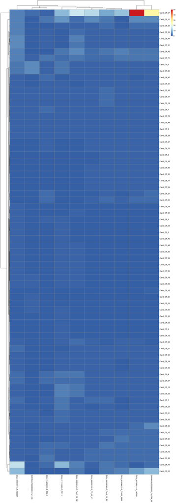

```r
#Build Pheatmap

#(USE CMD + Shft + c to uncomment all text and look at plots which help to explain why the heatmap must be transformed.)
pheatmap(Heatmap_data) #note:
```

*Fig 1. clustering of candidate effectors across the Foc genomes.*

Therefore, the data are log transformed, and now cluster more appropriately (race).

```r
# #Therefore, the data are log transformed.
# Effector_heatmap_data_log2_transformed <- log2(Heatmap_data+1)
# Effector_heatmap_data_log2_transformed
# pheatmap(Effector_heatmap_data_log2_transformed)
# # The genomes now cluster more appropriately.
```

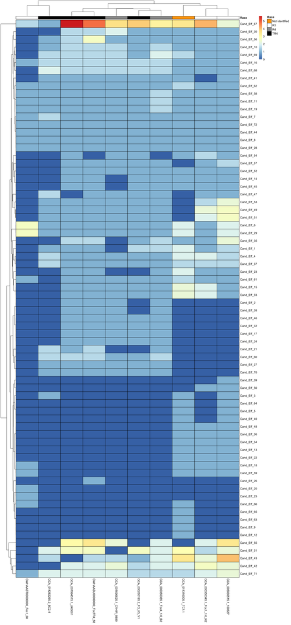

```r
#Now to tidy up the heatmap.
#Generate even breaks in the scale bar for the heatmap.
#Symmetric_breaks <- seq(-max(abs(Effector_heatmap_data_log2_transformed)), max(abs(Effector_heatmap_data_log2_transformed)), length.out = 101)

Symmetric_breaks <- seq(-max(0), max(abs(Effector_heatmap_data_log2_transformed)), length.out = 101)

#Add race annotations
data.frame(row.names = colnames(Heatmap_data),
           Race = c("TR4",  "R1",   "R4",   "R4",   "R1",   "TR4",  "Not identified",   "R1",   "TR4",  "TR4")) -> col_annotations
# print(col_annotations)

final_heatmap <- pheatmap(Effector_heatmap_data_log2_transformed,
                          border_color = "black",
                          breaks = Symmetric_breaks,
                          annotation_col = col_annotations,
                          annotation_colors = list(
                            Race = c("Not identified" = "orange",
                                     "R1" = "white",
                                     "R4" = "grey60",
                                     "TR4" = "black")))
```

*Fig 2. clustering of candidate effectors across the Foc genomes. Data are log transformed and race indicated.*